# Lecture 4 – Applications of NLP

SIMM59: Document Research in the Social Sciences 2026

nils.holmberg@iko.lu.se

## Presentation

- Nils Holmberg
- Computational  
  content analysis
- Cognitive  
  communication effects

[video not shown]

## Course literature

[figure not shown]

Ghosh and Gunning (2019)

[figure not shown]

Tight (2019)

[figure not shown]

Vasiliev (2020)

## Lecture overview

- `Applications of NLP`
- Keyword in context
- Knowledge graphs
- `Ch. 8: Sentiment analysis`
- Foundations and applications
- Dictionary vs. classifier
- Challenges and evaluation
- `Ch. 7: Text vectorization`
- Bag of Words
- Word Weighting
- Word Embeddings
- `Intro to computer lab 2`
- Plug in your text data
- Practice applying NLP!

## 1. Word Frequency

- Count how often each word appears in a text collection
- Common words reveal the dominant themes of a corpus
- Stop words removed so content words stand out
- Visualised as a word cloud — larger = more frequent
- Simple but effective first step in any text analysis

*Ch. 2, “Bag of Words” and “Word Clouds” (p. 55, 69)*

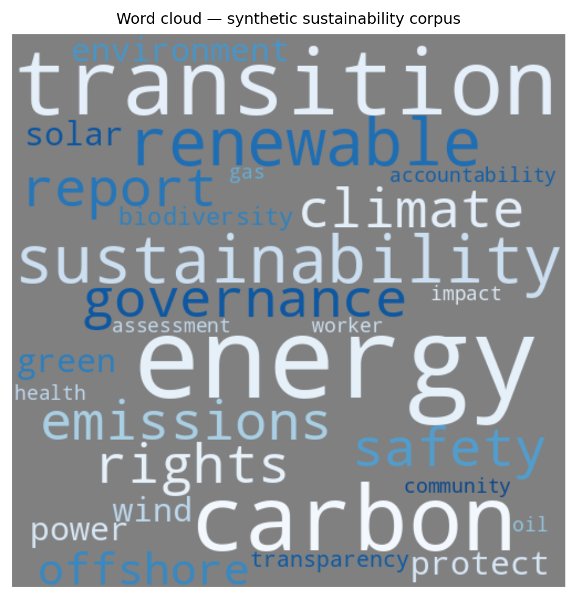

## 2. Keyword in Context (KWIC)

- Show every occurrence of a keyword with surrounding words
- Reveals how a word is actually used in the corpus
- Helps identify collocations and typical phrases
- Window size controls how many words left and right are shown
- Classical concordance tool from corpus linguistics

*Ch. 1, “Text Analytics and NLP” (p. 3)*

|  | left context | KEYWORD | right context |
| --- | --- | --- | --- |
| 0 | heavily in renewable | ENERGY | sources |
| 1 | The global | ENERGY | transition requires new |
| 2 | Clean | ENERGY | solutions help reduce |
| 3 |  | ENERGY | efficiency improvements are |

## 3. Sentiment Analysis

- Assign a positive or negative score to each document
- AFINN lexicon rates ~3,500 words from −5 to +5
- Score each token, then average across the document
- Positive score = net positive language; negative = net negative
- Quick overview of tone across a set of texts

*Ch. 8, “Sentiment Analysis” (p. 270)*

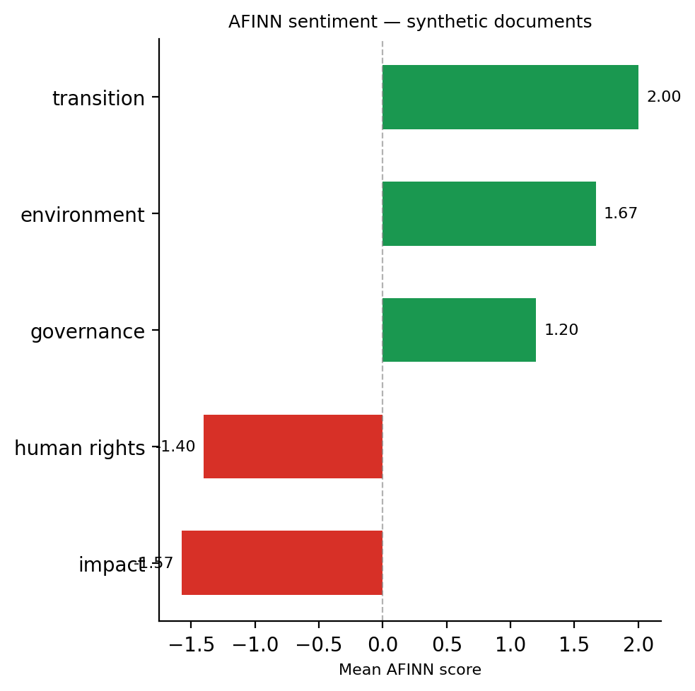

## 4. Named Entities and Knowledge Graph

- Named Entity Recognition (NER) identifies persons, organisations, places
- Part-of-Speech (POS) tagging labels verbs that express relations
- Entities become nodes; relations become edges in a graph
- Builds structured knowledge from unstructured text
- Foundation for question answering and information retrieval

*Ch. 1, “NER” (p. 18)*

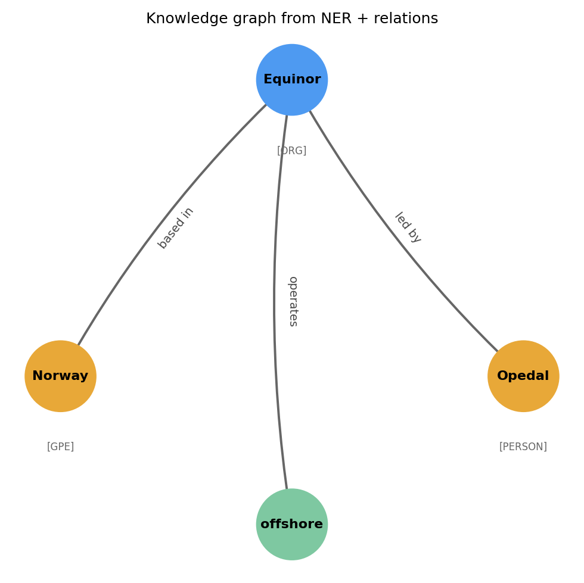

## 5. Document-Term Matrix

- Rows are documents, columns are vocabulary terms
- Each cell shows how often a term appears in a document
- Gives a numerical fingerprint for every document
- Shared high-frequency terms indicate topic overlap
- Heatmap reveals which terms distinguish each document

*Ch. 2, “Bag of Words” (p. 55–58)*

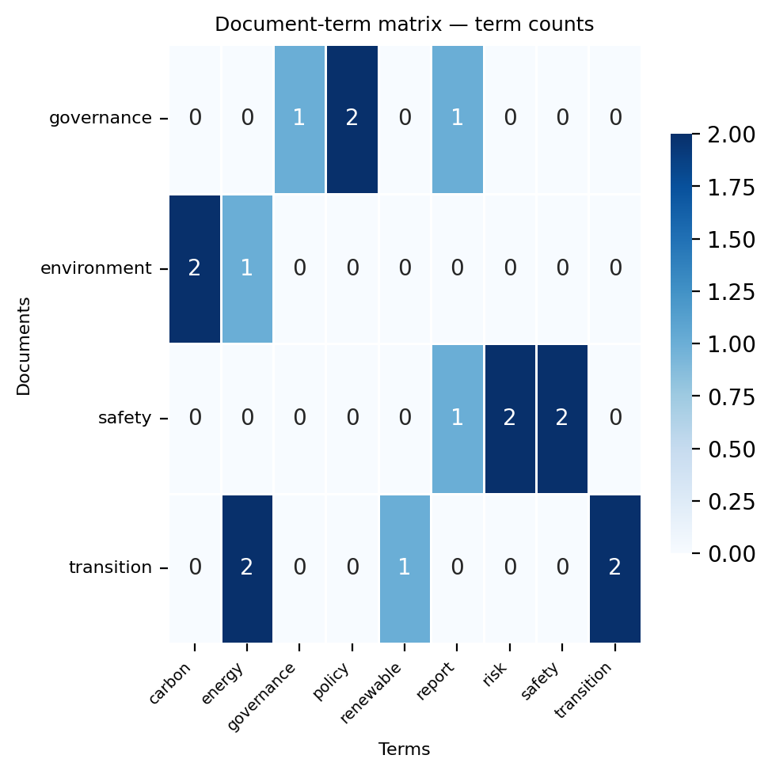

## 6. Word Vectors and Similarity

- Each word is placed as a point in a large numeric space
- Words with similar meanings land close to each other
- Plot in 2D using PCA to compress the dimensions
- Animals cluster together; royalty clusters together
- Word vectors power modern search, translation, and chat

*Ch. 7, “Word Embeddings” (p. 244–246)*

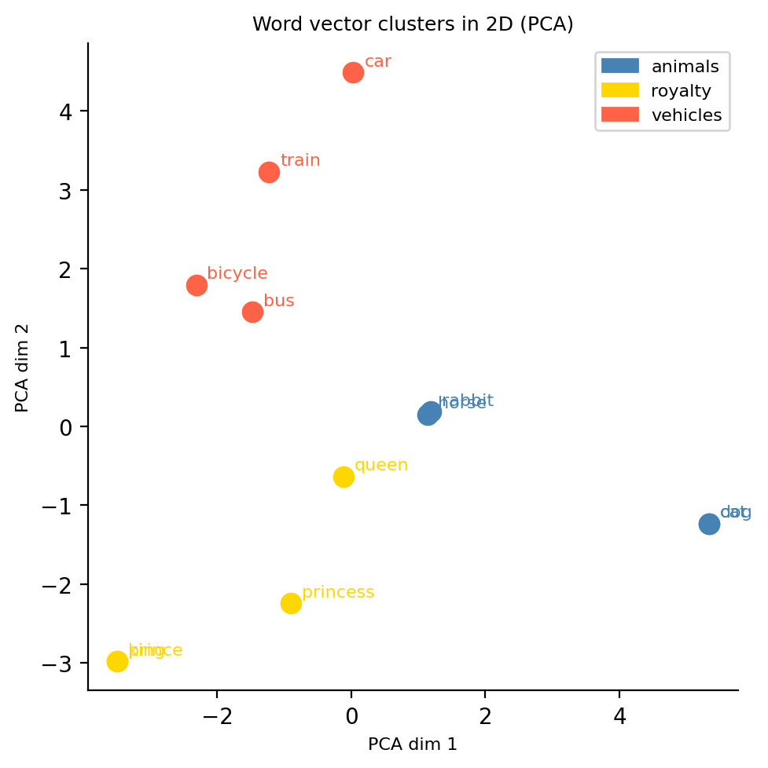

## Chapter 8: Sentiment Analysis

## What is Sentiment Analysis?

- Automatically detect the tone or mood of written text
- Output is a label: positive, negative, or neutral
- What humans do naturally — but cannot do at scale
- Driven by growth of online text and social media
- Relevant for brand research, finance, and organisational communication

*Ch. 8, “Introduction” (p. 270)*

|  | Input text | Sentiment | Why? |
| --- | --- | --- | --- |
| 0 | We are committed to reducing emissions. | positive | commitment language |
| 1 | Significant risks remain unaddressed. | negative | risk framing |
| 2 | Impact assessments are conducted annually. | neutral | factual statement |

## Types of Sentiment

- **Polarity** — is the text positive or negative?
- **Subjectivity** — is it an opinion or a fact?
- **Emotion** — happy, sad, angry, content?
- **Tone** — sarcasm, irony, humor (harder to detect)
- **Intensity** — how strongly expressed?

*Ch. 8, “Types of Sentiments” (p. 271–272)*

|  | Type | Question | Scale |
| --- | --- | --- | --- |
| 0 | Polarity | positive / negative? | −1 to +1 |
| 1 | Subjectivity | opinion or fact? | 0 to 1 |
| 2 | Emotion | which emotion? | categorical |
| 3 | Tone | sarcasm present? | binary flag |
| 4 | Intensity | how strongly? | 0 to 1 |

## Applications

- **Brand monitoring** — detect negative social media posts early
- **Financial markets** — predict price movements from news
- **Product reviews** — Amazon, Yelp satisfaction analysis
- **Customer service** — chatbot urgency detection
- **Organisational research** — analyse framing in corporate texts

*Ch. 8, “Applications of Sentiment Analysis” (p. 273–274)*

|  | Domain | Data source | Goal |
| --- | --- | --- | --- |
| 0 | Finance | News articles | Price prediction |
| 1 | E-commerce | Product reviews | Improve products |
| 2 | Social media | Twitter/X | Brand risk alert |
| 3 | Customer service | Chat transcripts | Detect intent |
| 4 | Corp. communication | Sustainability reports | Tone analysis |

## Sentiment Analysis Tools

- **Cloud APIs** — AWS, Google, IBM; no ML knowledge needed
- **Lexicon / dictionary** — AFINN, VADER; transparent, no training
- **Python NLP libraries** — TextBlob, spaCy; simple API
- **ML classifiers** — TF-IDF features with logistic regression
- **Deep learning** — BERT, RoBERTa; highest accuracy

*Ch. 8, “Tools Used for Sentiment Analysis” (p. 274–276)*

|  | Approach | Example | Training data | Transparency |
| --- | --- | --- | --- | --- |
| 0 | Dictionary | AFINN, VADER | None | High |
| 1 | TextBlob | textblob | None | Medium |
| 2 | ML classifier | TF-IDF + LogReg | Labelled text | Low |
| 3 | Deep learning | BERT | Large corpus | Very low |

## AFINN: Dictionary-Based Scoring

- About 3,500 English words each given a score from −5 to +5
- Positive words: *good*, *safe*, *excellent*, *committed*
- Negative words: *risk*, *harm*, *failure*, *damage*
- Look up each token, sum or average across the document
- Fully transparent — every score can be inspected

*Ch. 8 (AFINN referenced); Nielsen (2011)*

|  | token | AFINN score |
| --- | --- | --- |
| 0 | protect | 1.0 |
| 1 | risk | -2.0 |
| 2 | harm | -2.0 |
| 3 | excellent | 3.0 |
| 4 | challenge | -1.0 |
| 5 | commit | 1.0 |
| 6 | safe | 1.0 |
| 7 | failure | -2.0 |

## AFINN Results: Equinor Corpus

- Most texts score mildly positive — typical corporate register
- *Impact Assessments* scores slightly negative — more analytical
- Only 3–15% of tokens match AFINN; domain vocab not covered
- Scores are very small because most tokens receive zero
- Useful first pass; does not capture all nuance

*Lab 2, Part 1 — AFINN Sentiment Analysis*

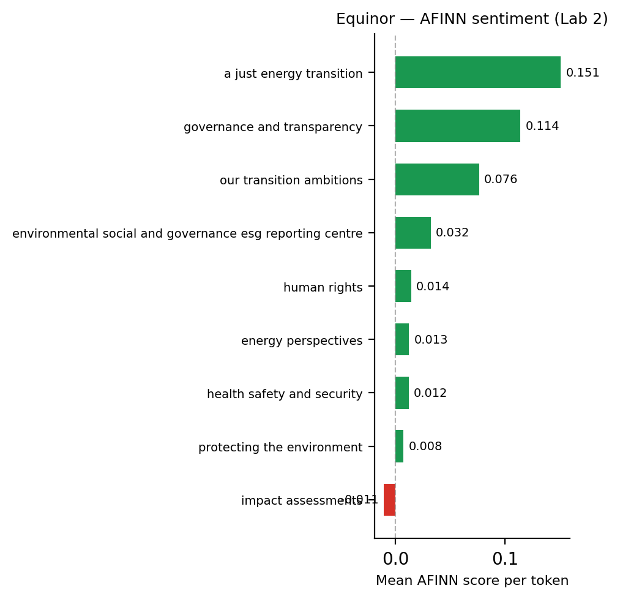

## When Dictionaries Go Wrong

- Dictionary methods score each word independently
- **Negation** — *not harmful* still scores harmful as −2
- **Context** — *reduce risk* looks like mixed, not positive
- **Domain gap** — AFINN trained on social media, not corporate text
- **Missing words** — most technical terms score zero

*Ch. 8, “Key Ideas and Terms” (p. 272)*

[output not shown]

## TextBlob: Polarity and Subjectivity

- One-line Python API built on NLTK
- Returns two scores per sentence: polarity and subjectivity
- Polarity ranges from −1 (negative) to +1 (positive)
- Subjectivity ranges from 0 (factual) to 1 (opinionated)
- Handles some adjective and adverb modifiers automatically

*Ch. 8, “TextBlob” (p. 277–278)*

```python
sentences = [
    "Equinor is committed to reducing its carbon emissions.",
    "Significant risks and challenges remain unaddressed.",
    "Impact assessments are conducted on all new projects.",
]
rows_tb = []
for s in sentences:
    blob = TextBlob(s)
    rows_tb.append({"sentence": s[:42]+"…",
                    "polarity": round(blob.sentiment.polarity, 2),
                    "subjectivity": round(blob.sentiment.subjectivity, 2)})
pd.DataFrame(rows_tb)
```

|  | sentence | polarity | subjectivity |
| --- | --- | --- | --- |
| 0 | Equinor is committed to reducing its carbo… | 0.00 | 0.00 |
| 1 | Significant risks and challenges remain un… | 0.38 | 0.88 |
| 2 | Impact assessments are conducted on all ne… | 0.14 | 0.45 |

## Training a Classifier

- Need labelled data — each text paired with a sentiment label
- Convert text to numbers using TF-IDF word frequencies
- Train a classifier to predict the label from those numbers
- Split data into training and test sets to evaluate accuracy
- Exercise 65 in Ch. 8 achieves 89% accuracy on review data

*Ch. 8, “Training Sentiment Models” (p. 284–288)*

```python
texts  = ["great sustainability commitment",
          "risk and harm assessment needed",
          "excellent energy transition progress",
          "significant environmental damage",
          "committed to reducing emissions",
          "challenges and failures in governance"]
labels = [1, 0, 1, 0, 1, 0]

model = Pipeline([("tfidf", TfidfVectorizer()),
                  ("clf",   LogisticRegression())])
model.fit(texts, labels)
test = ["carbon transition opportunity",
        "serious environmental risk failure"]
preds = model.predict(test)
pd.DataFrame({"text": [t[:35]+"…" for t in test],
              "predicted": ["positive" if p else "negative"
                            for p in preds]})
```

|  | text | predicted |
| --- | --- | --- |
| 0 | carbon transition opportunity… | positive |
| 1 | serious environmental risk failure… | negative |

## Why Dictionary Methods Are Not Enough

- Dictionary lookup treats every word as isolated
- Words have meaning through *context* — neighbouring words
- *bank* can mean finance or riverbank depending on context
- *transition* can be positive (opportunity) or disruptive
- To capture meaning, we need a richer way to represent words

*Bridge: Ch. 8 → Ch. 7*

[output not shown]

## Chapter 7: Vector Representation

## Text Must Become Numbers

- Computers process numbers, not words
- Every NLP method converts text to a numeric format first
- The choice of representation shapes what the algorithm can learn
- Simple representations are fast but lose information
- Richer representations capture more meaning

*Ch. 7, “Introduction” and “Why Vector Representations?” (p. 220–222)*

|  | Representation | What it captures | Complexity |
| --- | --- | --- | --- |
| 0 | Character codes | Character identity | Very low |
| 1 | One-hot | Word identity | Low |
| 2 | Bag of Words | Word counts | Low |
| 3 | TF-IDF | Relative importance | Medium |
| 4 | Word embeddings | Meaning and context | High |

## Counting Words: Bag of Words

- Represent each document as a table of word counts
- Word order and sentence structure are discarded
- Simple and surprisingly effective as a baseline
- Two documents with the same words look identical
- The starting point for most text classification tasks

*Ch. 2, “Bag of Words” (p. 55)*

|  | doc A | doc B | doc C |
| --- | --- | --- | --- |
| carbon | 1 | 2 | 0 |
| energy | 2 | 1 | 1 |
| policy | 0 | 0 | 1 |
| risk | 0 | 1 | 1 |
| transition | 1 | 0 | 1 |

## One-Hot Encoding

- Each word in the vocabulary gets its own column
- A word is represented as a row of zeros with a single one
- Clean and unambiguous — no two words look the same
- Very large and memory-hungry for big vocabularies
- No similarity information: *cat* and *dog* look equally different from *cat* and *fish*

*Ch. 7, “One-Hot Encoding” (p. 228–238)*

|  | cat | dog | king | queen |
| --- | --- | --- | --- | --- |
| cat | 1 | 0 | 0 | 0 |
| dog | 0 | 1 | 0 | 0 |
| king | 0 | 0 | 1 | 0 |
| queen | 0 | 0 | 0 | 1 |

## TF-IDF: Rewarding Rare Words

- Raw counts favour common words like *the*, *is*, *and*
- TF-IDF down-weights words that appear in every document
- Words that are frequent in one doc but rare elsewhere score highest
- *konsekvensutredning* in one file → high TF-IDF score
- Standard approach before word embeddings became common

*Ch. 2, “TF-IDF” (p. 62–65)*

|  | carbon | emission | energy | policy | transition |
| --- | --- | --- | --- | --- | --- |
| doc A | 0.0 | 0.00 | 0.19 | 0.00 | 0.1 |
| doc B | 0.1 | 0.23 | 0.10 | 0.00 | 0.0 |
| doc C | 0.1 | 0.00 | 0.00 | 0.23 | 0.1 |

## The Limits of Counting

- Bag of Words and TF-IDF treat every word as unrelated
- *car* and *automobile* look completely different
- *not good* is treated as two separate positive/neutral words
- No sense of distance or similarity between words
- We need a representation that encodes meaning

*Ch. 7, “Word Embeddings” (p. 244–246)*

|  | Problem | Example | BoW/TF-IDF | Impact |
| --- | --- | --- | --- | --- |
| 0 | Synonyms | car vs automobile | treated as different | missed similarity |
| 1 | Negation | not good | split into 2 words | wrong polarity |
| 2 | Polysemy | bank | one entry only | ambiguous |
| 3 | Domain terms | konsekvensutredning | unknown word | score zero |

## Word Embeddings: Words as Positions

- Each word becomes a point in a space with hundreds of dimensions
- Words used in similar contexts end up near each other
- *cat* and *dog* are close; *cat* and *democracy* are far apart
- Arithmetic works: *king* − *man* + *woman* lands near *queen*
- Meaning comes from the company a word keeps

*Ch. 7, “Word Embeddings” (p. 244–246)*

```python
pairs = [("cat","dog"),("king","queen"),
         ("man","woman"),("cat","king")]
rows_sim = []
for w1, w2 in pairs:
    v1 = nlp(w1)[0].vector
    v2 = nlp(w2)[0].vector
    sim = cosine_sim(v1, v2)
    rows_sim.append({"word 1": w1, "word 2": w2,
                     "similarity": round(sim, 3)})
pd.DataFrame(rows_sim)
```

|  | word 1 | word 2 | similarity |
| --- | --- | --- | --- |
| 0 | cat | dog | 1.000 |
| 1 | king | queen | 0.383 |
| 2 | man | woman | 0.156 |
| 3 | cat | king | 0.164 |

## Seeing the Semantic Space

- 300-dimensional vectors cannot be drawn directly
- PCA compresses them to 2 dimensions for visualisation
- Semantically related words cluster together in the plot
- Animals, royalty, and vehicles form separate groups
- This is the geometric structure word embeddings learn

*Ch. 7, “Using Pre-Trained Word Vectors” (p. 252–259)*

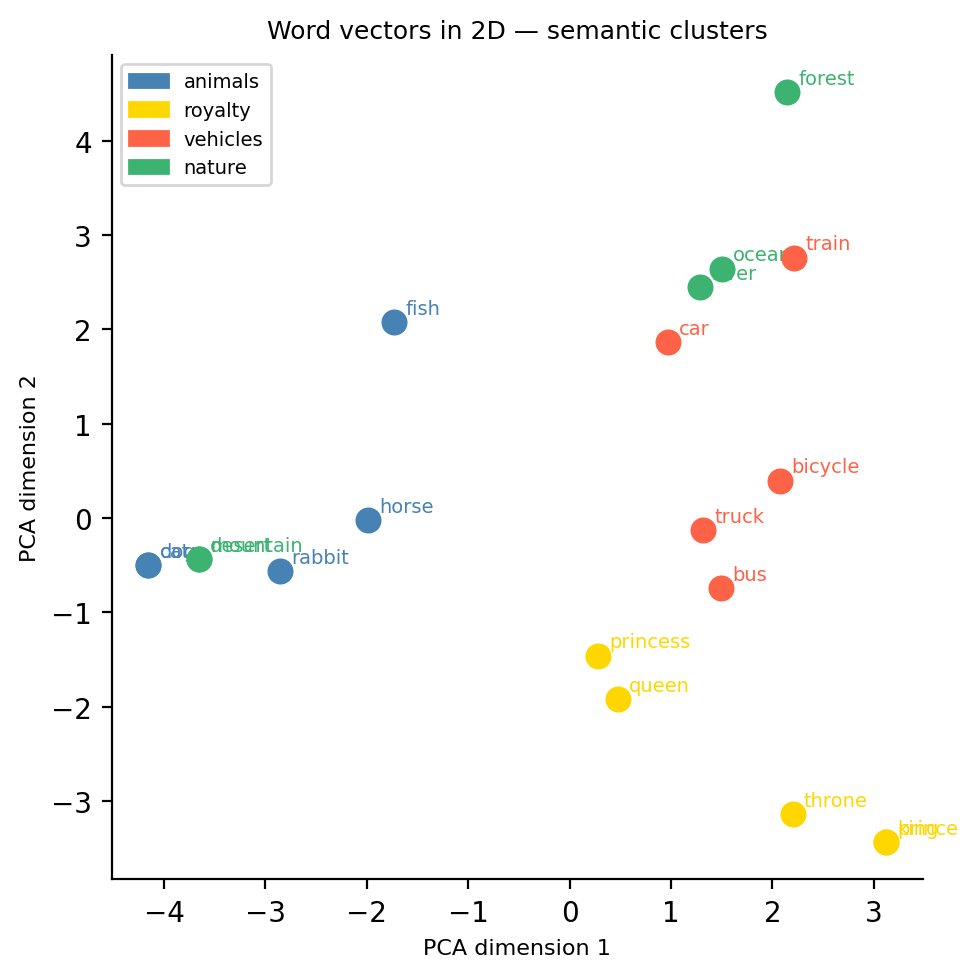

## Pre-trained Vectors: Transfer Learning

- Train vectors once on a very large text collection
- Reuse those vectors on a new, smaller project
- Called **transfer learning** — carry knowledge across tasks
- spaCy `en_core_web_md` ships 300-dim vectors for 20,000 words
- Vectors were learned from news and web text (GloVe method)

*Ch. 7, “Using Pre-Trained Word Vectors” (p. 252)*

```python
#sample_words = ["energy","carbon","transition",
#                "risk","governance","sustainability"]
sample_words = ["energy","carbon","transition","risk"]
pd.DataFrame({
    "word": sample_words,
    "vector length": [len(nlp(w)[0].vector) for w in sample_words],
    "has vector": [nlp(w)[0].has_vector for w in sample_words],
    "first 3 dims": [str(nlp(w)[0].vector[:3].round(2).tolist())
                     for w in sample_words]
})
```

|  | word | vector length | has vector | first 3 dims |
| --- | --- | --- | --- | --- |
| 0 | energy | 300 | True | [-0.699999988079071, 0.09000000357627869, 0.31... |
| 1 | carbon | 300 | True | [-0.6800000071525574, 0.28999999165534973, -0.... |
| 2 | transition | 300 | True | [-0.7799999713897705, 0.9300000071525574, -0.1... |
| 3 | risk | 300 | True | [-0.6700000166893005, 0.25999999046325684, -0.... |

## Document Vectors: One Vector Per Text

- A document vector is the average of all its word vectors
- One compact representation for an entire document
- Compare documents by measuring the angle between their vectors
- Similar topics produce similar vectors pointing in the same direction
- Uses: find similar texts, cluster, build classifiers

*Ch. 7, “Document Vectors” (p. 259–265)*

[figure not shown]

## Vectors Back to Sentiment

- Create a positive seed text and a negative seed text
- Compute vectors for each seed using the same model
- Score a sentence by how close it is to each seed vector
- Captures meaning of the whole sentence, not isolated words
- First step toward contextual models like BERT

*Lab 2, bridge cell — Ch. 7 into Ch. 8*

```python
pos_anchor = nlp("good excellent benefit success opportunity safe")
neg_anchor = nlp("risk harm damage failure loss problem")

test_sents = [
    "Equinor is committed to reducing emissions.",
    "Significant risks remain unaddressed.",
    "Impact assessments identify potential hazards.",
]
rows_va = []
for s in test_sents:
    doc = nlp(s)
    net = round(doc.similarity(pos_anchor) - doc.similarity(neg_anchor), 3)
    rows_va.append({"sentence": s[:38]+"…", "net sentiment": net,
                    "label": "positive" if net > 0 else "negative"})
pd.DataFrame(rows_va)
```

|  | sentence | net sentiment | label |
| --- | --- | --- | --- |
| 0 | Equinor is committed to reducing emiss… | 0.050 | positive |
| 1 | Significant risks remain unaddressed.… | -0.034 | negative |
| 2 | Impact assessments identify potential … | -0.105 | negative |

## Computer Lab Overview

- The lab uses Jupyter notebooks.
- Work proceeds step by step in cells.
- Students test code and inspect outputs.
- Markdown records decisions and interpretations.
- Notebooks support reproducible mini-projects.

[figure not shown]

## Next steps

**Lecture, lab 2**

- Lecture notes: [available on github!](https://cca-cce.github.io/osm-comm/web/edu/simm59-lecture2-nlp.html)
- Lab notebook: [check canvas page!](https://canvas.education.lu.se/courses/38917)

**References**

Ghosh, Sohom, and Dwight Gunning. 2019. *Natural Language Processing Fundamentals: Build Intelligent Applications That Can Interpret the Human Language to Deliver Impactful Results*. Packt Publishing Ltd.

Tight, Malcolm. 2019. *Documentary Research in the Social Sciences*.

Vasiliev, Yuli. 2020. *Natural Language Processing with Python and spaCy: A Practical Introduction*. No Starch Press.